# Informe 2

José Matus

2023-04-12

```r
library(dplyr)
library(ggplot2)
library(readxl)
library(moments)
library(tidyverse)
library(nortest)
library(gridExtra)
library(fitdistrplus)
```

```r
base_datos <- read_excel("C:/Users/jose/Downloads/MATUS_TORO_JOSE (1).xlsx")
```

# Propósito de la investigación

El análisis presente en este informe será para comprender de mejor manera cómo afecta el NO2 (dióxido de nitrógeno) y el SO2 (dióxido de azufre) a la población, para esto, usaremos distribuciones de probabilidad y así predecir algunos acontecimientos que podrían afectar a las personas

# Analisis NO2

## Limpieza de datos

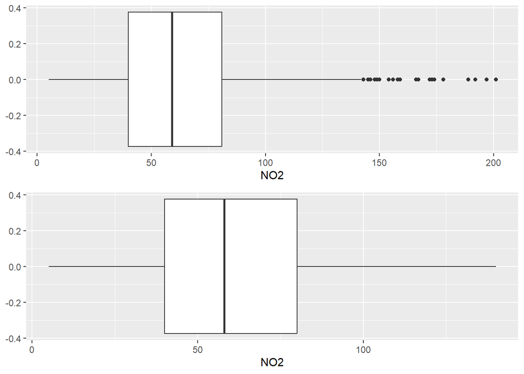

```r
cajaNo2 = base_datos %>%
  ggplot(aes(y=NO2)) +
  geom_boxplot() +
  coord_flip()

no2modificado = base_datos %>% filter(NO2 < 142) %>%
  ggplot(aes(y=NO2)) +
  geom_boxplot() +
  coord_flip()

grid.arrange(cajaNo2,no2modificado)
```

El primer grafico muestra los datos sin modificar mientras que el segundo muestra una versión sin los datos atípicos, analizando la muestra de NO2, podemos ver que los datos atípicos empiezan aparecer cuando la concentración de dióxido de nitrógeno supera los 142. Ejecutando el siguiente código:

```r
datos_atipicos = base_datos %>% filter(NO2 > 142)
nrow(base_datos) - (nrow(base_datos) - nrow(datos_atipicos))
```

```
## [1] 28
```

Se puede apreciar finalmente que hay 28 datos que superan la cifra anterior, considerando que el total es de 1201, un total de 28 datos solo equivale al 2.3% aproximadamente por ende, para este caso, trabajaremos sin estos datos ya que la información fue extraída a lo largo de un año y estos datos atípicos se pueden deber a casos muy puntuales donde el NO2 aumenta, como por ejemplo, un incendio o una gran aglomeración de autos

## Definición del experimento (Binomial)

Considerando que si el NO2 en el aire es mayor a 70 se considera dañino, si se toma una muestra de 30 estudios de NO2 ¿Cuál es la probabilidad de que en esta muestra como mucho haya 10 estudios de NO2 dañinos?

Para resolver el experimento planteado primero debemos calcular la probabilidad de que el no2 sea dañino, para esto utilizamos el siguiente código:

```r
no2modificado = base_datos %>% filter(NO2 < 142)
no2 = no2modificado

base_datosNO2 = no2 %>%
  mutate(NO2_alto = ifelse(NO2 >= 70,1,0))
probs = NULL
n1 = round(length(base_datosNO2$NO2)*0.2,0)
for (i in 1:1000) {
  sample.aux = base_datosNO2$NO2_alto %>% sample(n1,replace=F)
  probs = c(probs,mean(sample.aux))

}
p = mean(probs)
p
```

```
## [1] 0.3516966
```

Una vez poseer la probabilidad tenemos:

- X : Estudios de NO2 que resultan ser dañinos
- Exito: NO2 dañino
- Fracaso: NO2 no dañino
- N = 30
- P = 0.35
- P(X <= 10)

Calculando:

```r
pbinom(10,30,p)
```

```
## [1] 0.4999214
```

## Definición del experimento (Poisson)

Considerando que si el NO2 en el aire es menor o igual a 20 se considera estable y sabiendo que los estudios se realizan cada hora. Calcular cuál es la probabilidad de que hayan mas de 5 estudios estables en una hora dada

Para resolver esto lo primero es calcular el valor de lambda:

```r
n1 = ceiling(dim(base_datosNO2)[1]*0.3)

base_datosNO2 = no2 %>%
  mutate(NO2_estable = ifelse(NO2 <= 20,1,0))


lambdas = NULL

for (i in 1:100) {
  sample.aux = base_datosNO2 %>%  slice(sample(1:dim(base_datosNO2)[1],size=n1)) %>%
    group_by(hour) %>% dplyr::summarise(tasa = sum(NO2_estable))
  tasa.aux = mean(sample.aux$tasa)
  lambdas = c(lambdas,tasa.aux)

}

lambda = ceiling(mean(lambdas))
lambda
```

```
## [1] 2
```

Con el valor de lambda tenemos que:

- X: Estudios de NO2 que resultan ser estables
- Exito: NO2 estable
- Fracaso: NO2 no estable
- λ = 2
- P(X > 5) = 1 – P(X <= 5)

Calculando:

```r
1 - dpois(5,2)
```

```
## [1] 0.9639106
```

# Analisis SO2

## Limpieza de datos

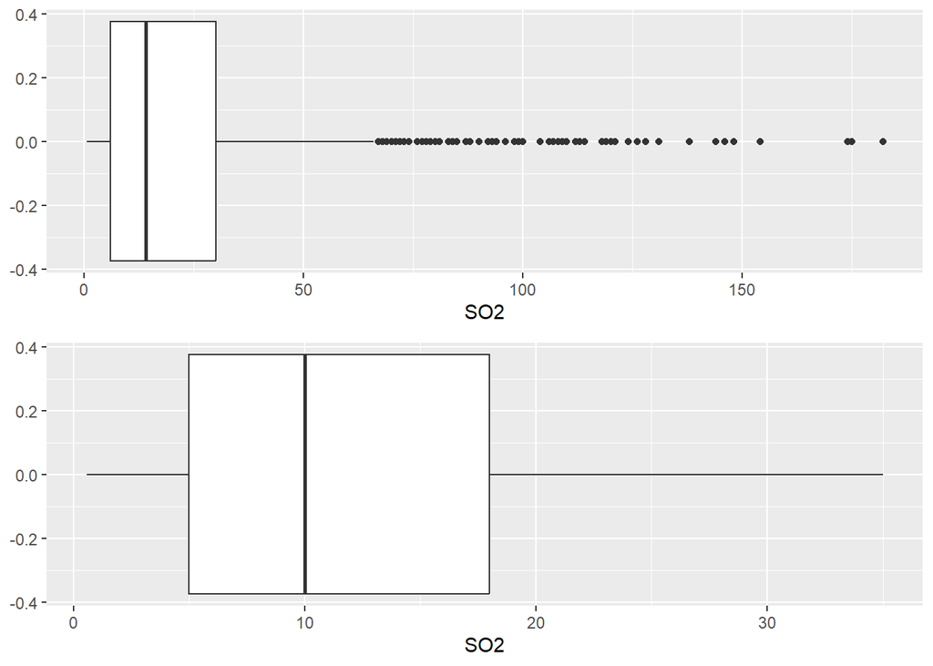

```r
cajaSo2 = base_datos %>%
  ggplot(aes(y=SO2)) +
  geom_boxplot() +
  coord_flip()

so2modificado = base_datos %>% filter(SO2 < 36) %>%
  ggplot(aes(y=SO2)) +
  geom_boxplot() +
  coord_flip()

grid.arrange(cajaSo2,so2modificado)
```

```r
base_datos = base_datos
datos_atipicos = base_datos %>% filter(SO2 > 36)
nrow(base_datos) - (nrow(base_datos) - nrow(datos_atipicos))
```

```
## [1] 251
```

## Definición del experimento (Binomial negativo)

Dado que el valor normal del SO2 en el aire es de 20. Calcular la probabilidad de que sea necesario realizar 15 estudios para que se logren 5 mediciones normales

```r
base_datosSO2 = base_datos %>%
  mutate(SO2_alto = ifelse(SO2 >= 20,1,0))

probs = NULL
n1 = round(length(base_datosSO2$SO2)*0.2,0)
for (i in 1:1000) {
  sample.aux = base_datosSO2$SO2_alto %>% sample(n1,replace=F)
  probs = c(probs,mean(sample.aux))

}
p = mean(probs)
p
```

```
## [1] 0.3796708
```

Con el calculo de la probabilidad tenemos que:

```r
dnbinom(10,5,p)
```

```
## [1] 0.06663345
```

# Casos continuos

## NO2

Para el NO2 haremos diferentes tipos de test para comprobar que distribución continua se ajusta mejor a los datos

```r
no2 = base_datos$NO2
no2modificado = (base_datos %>% filter(NO2 < 142))$NO2

no2 = no2modificado

fw <-fitdist(no2,"weibull")
fln<-fitdist(no2,"lnorm")
fg <-fitdist(no2,"gamma")
fn <-fitdist(no2,"norm")
fe <-fitdist(no2,"exp")
# fb <-fitdist(no2,"beta") no se mueve entre 0 y 1
plot.legend<-c("Weibull","LogNormal","Gamma","Normal","Exponencial")
```

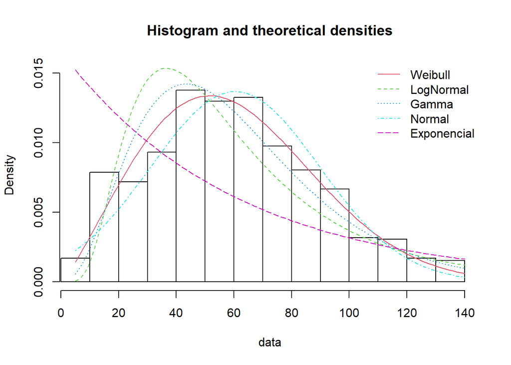

```r
denscomp(list(fw,fln,fg,fn,fe), legendtext=plot.legend)
```

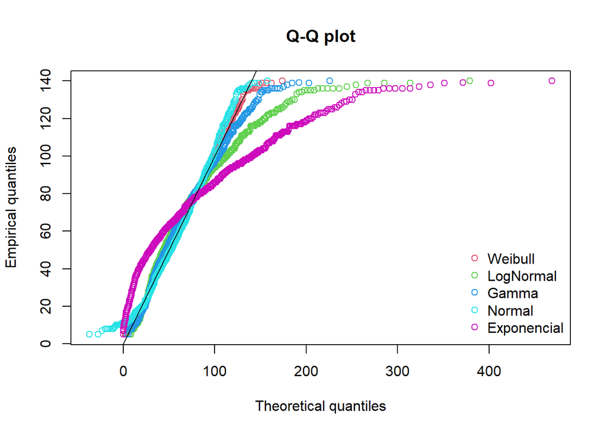

```r
qqcomp(list(fw,fln,fg,fn,fe), legendtext=plot.legend)
```

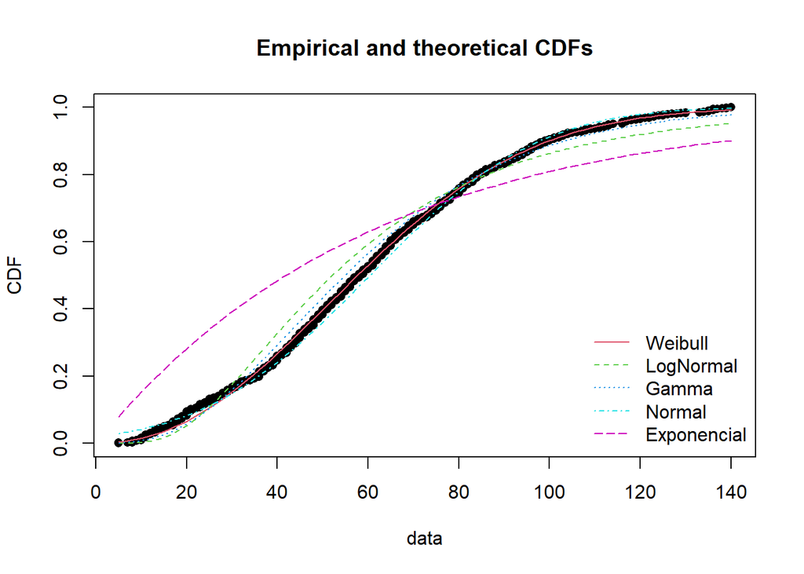

```r
cdfcomp(list(fw,fln,fg,fn,fe), legendtext=plot.legend)
```

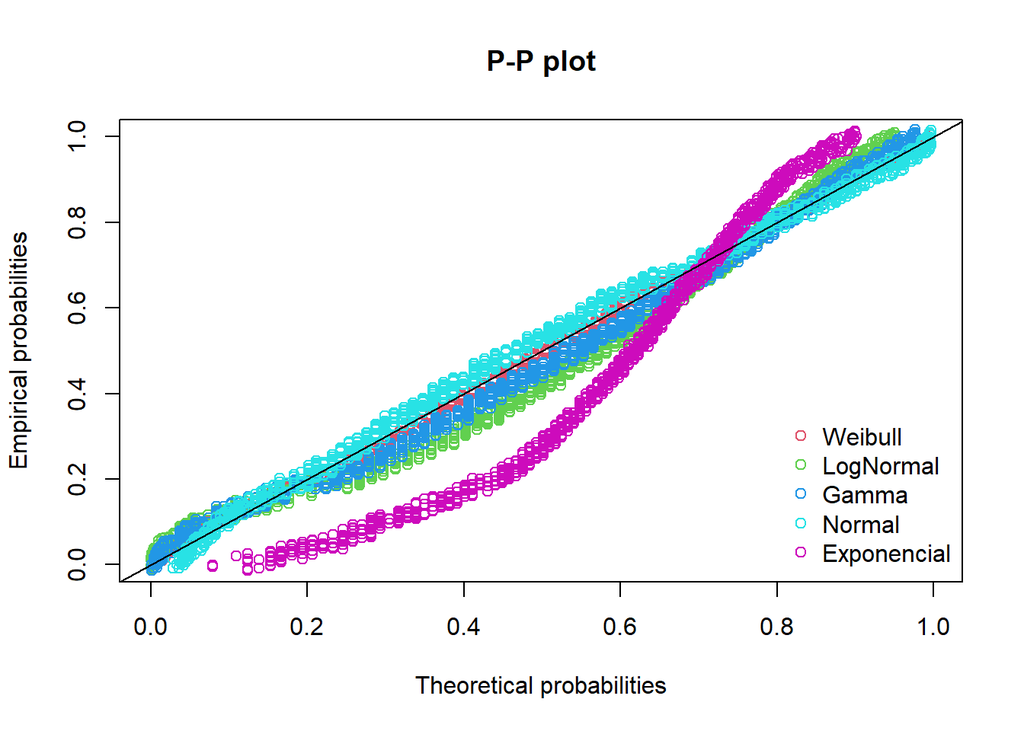

```r
ppcomp(list(fw,fln,fg,fn,fe), legendtext=plot.legend)
```

Para empezar, descartamos la distribución beta debido a que los datos no se mueven entre 1 y 0. Viendo los cuatro gráficos podemos descartar de forma la inmediata la distribución exponencial

```r
gofstat(list(fg,fn,fln,fw))
```

```
## Goodness-of-fit statistics
##                              1-mle-gamma 2-mle-norm 3-mle-lnorm 4-mle-weibull
## Kolmogorov-Smirnov statistic  0.05505407 0.04217787  0.09331791    0.02969453
## Cramer-von Mises statistic    1.06971197 0.47683127  3.29065486    0.12258082
## Anderson-Darling statistic    6.85462857 3.64752617 20.29127866    1.17630405
##
## Goodness-of-fit criteria
##                                1-mle-gamma 2-mle-norm 3-mle-lnorm 4-mle-weibull
## Akaike's Information Criterion    11201.75   11218.21    11361.26      11139.55
## Bayesian Information Criterion    11211.88   11228.34    11371.39      11149.68
```

Con el criterio de Akaike podemos ver que la distribución que mas se acomoda es la de Weibull, sin embargo, la normal también se ajusta bien por lo tanto seguiremos al siguiente test con estas dos

```r
ks.test(no2,"pweibull",shape=fw$estimate[1],scale=fw$estimate[2])
```

```
##
##  Asymptotic one-sample Kolmogorov-Smirnov test
##
## data:  no2
## D = 0.029695, p-value = 0.2535
## alternative hypothesis: two-sided
```

```r
ks.test(no2,"pnorm",fn$estimate[1],fn$estimate[2])
```

```
##
##  Asymptotic one-sample Kolmogorov-Smirnov test
##
## data:  no2
## D = 0.042178, p-value = 0.03113
## alternative hypothesis: two-sided
```

Viendo los resultados del KS test y considerando los resultados anteriores, se puede decir con seguridad que la distribución continua que mejor se ajusta es la de Weibull debido a que tiene un valor mayor a 0.05 en el p-value

## SO2

Al igual que en el caso anterior, la función beta es descartada inmediata debido a que los datos no se mueven entre el 0 y el 1, teniendo en cuanta lo anterior, procederemos a realizar los mismos test que con el NO2:

```r
SO2 = base_datos$SO2
fw <-fitdist(SO2,"weibull")
fln<-fitdist(SO2,"lnorm")
fg <-fitdist(SO2,"gamma")
fn <-fitdist(SO2,"norm")
fe <-fitdist(SO2,"exp")
plot.legend<-c("Weibull","LogNormal","Gamma","Normal","Exponencial")
```

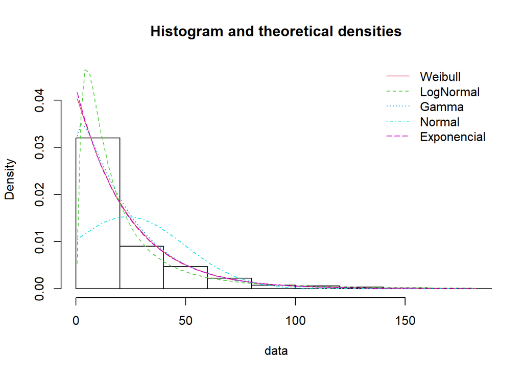

```r
denscomp(list(fw,fln,fg,fn,fe), legendtext=plot.legend)
```

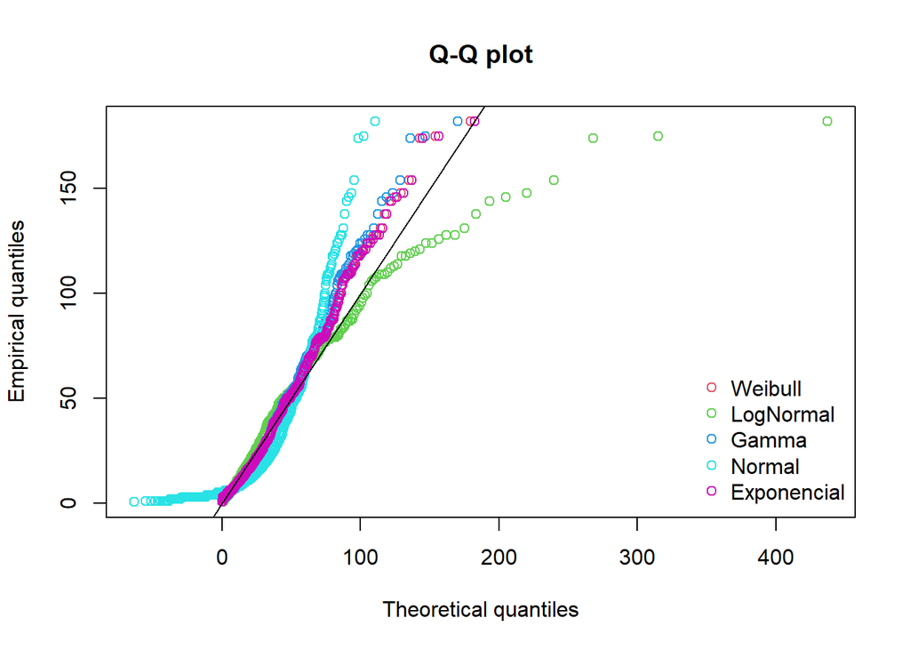

```r
qqcomp(list(fw,fln,fg,fn,fe), legendtext=plot.legend)
```

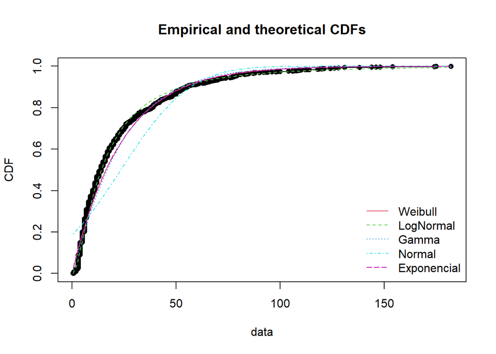

```r
cdfcomp(list(fw,fln,fg,fn,fe), legendtext=plot.legend)
```

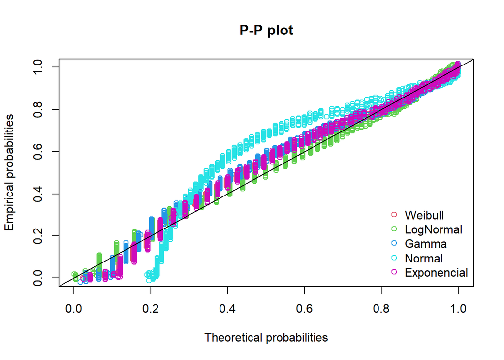

```r
ppcomp(list(fw,fln,fg,fn,fe), legendtext=plot.legend)
```

Viendo los gráficos podemos descartar la distribución normal, siendo esta la menos se ajusta visualmente

```r
gofstat(list(fg,fln,fw,fe))
```

```
## Goodness-of-fit statistics
##                              1-mle-gamma 2-mle-lnorm 3-mle-weibull   4-mle-exp
## Kolmogorov-Smirnov statistic   0.0867749  0.06051695    0.09220569  0.09519768
## Cramer-von Mises statistic     2.8720886  0.55207409    2.18295828  2.06128790
## Anderson-Darling statistic    16.7623089  4.09095175   14.69580489 14.38958460
##
## Goodness-of-fit criteria
##                                1-mle-gamma 2-mle-lnorm 3-mle-weibull 4-mle-exp
## Akaike's Information Criterion    9973.479    9827.527      9981.829  9980.073
## Bayesian Information Criterion    9983.661    9837.708      9992.011  9985.164
```

```r
ks.test(SO2,"plnorm",meanlog=fln$estimate[1],sdlog=fln$estimate[2])
```

```
##
##  Asymptotic one-sample Kolmogorov-Smirnov test
##
## data:  SO2
## D = 0.060517, p-value = 0.0003024
## alternative hypothesis: two-sided
```